Skip to contents

# explore_data

Source: [`vignettes/articles/explore_data.Rmd`](https://github.com/adrientaudiere/MiscMetabar/blob/HEAD/vignettes/articles/explore_data.Rmd)

```r
library(MiscMetabar)
data(data_fungi)
```

```r
summary_plot_pq(data_fungi)
```

[figure not shown]

#### Explore samples metadata

```r
sam_tab <- tibble::as_tibble(unclass(data_fungi@sam_data))
```

```r
summarytools::dfSummary(sam_tab)




```

```
#> Warning in png(png_loc <- tempfile(fileext = ".png"), width = 150 *
#> graph.magnif, : unable to open connection to X11 display ''
#> Data Frame Summary
#> sam_tab
#> Dimensions: 185 x 7
#> Duplicates: 0
#>
#> --------------------------------------------------------------------------------------------------------------------
#> No   Variable       Stats / Values                  Freqs (% of Valid)    Graph                 Valid      Missing
#> ---- -------------- ------------------------------- --------------------- --------------------- ---------- ---------
#> 1    X              1. A10-005-B_S188_MERGED.fas      1 ( 0.5%)                                 185        0
#>      [character]    2. A10-005-H_S189_MERGED.fas      1 ( 0.5%)                                 (100.0%)   (0.0%)
#>                     3. A10-005-M_S190_MERGED.fas      1 ( 0.5%)
#>                     4. A12-007_S191_MERGED.fastq      1 ( 0.5%)
#>                     5. A12-007-B_S2_MERGED.fastq      1 ( 0.5%)
#>                     6. A15-004_S3_MERGED.fastq.g      1 ( 0.5%)
#>                     7. A8-005_S4_MERGED.fastq.gz      1 ( 0.5%)
#>                     8. A9-012_S5_MERGED.fastq.gz      1 ( 0.5%)
#>                     9. AB29-ABMX-H_S6_MERGED.fas      1 ( 0.5%)
#>                     10. AC27-013_S7_MERGED.fastq.     1 ( 0.5%)
#>                     [ 175 others ]                  175 (94.6%)           IIIIIIIIIIIIIIIIII
#>
#> 2    Sample_names   1. A10-005-B_S188                 1 ( 0.5%)                                 185        0
#>      [character]    2. A10-005-H_S189                 1 ( 0.5%)                                 (100.0%)   (0.0%)
#>                     3. A10-005-M_S190                 1 ( 0.5%)
#>                     4. A12-007_S191                   1 ( 0.5%)
#>                     5. A12-007-B_S2                   1 ( 0.5%)
#>                     6. A15-004_S3                     1 ( 0.5%)
#>                     7. A8-005_S4                      1 ( 0.5%)
#>                     8. A9-012_S5                      1 ( 0.5%)
#>                     9. AB29-ABMX-H_S6                 1 ( 0.5%)
#>                     10. AC27-013_S7                   1 ( 0.5%)
#>                     [ 175 others ]                  175 (94.6%)           IIIIIIIIIIIIIIIIII
#>
#> 3    Tree_name      1. AD30-abm-X                     4 ( 2.2%)                                 185        0
#>      [character]    2. A10-005                        3 ( 1.6%)                                 (100.0%)   (0.0%)
#>                     3. AD26-005                       3 ( 1.6%)
#>                     4. BB6-019                        3 ( 1.6%)
#>                     5. BE9-006                        3 ( 1.6%)
#>                     6. BG7-010                        3 ( 1.6%)
```

[output cut: 18 more lines]

```
#>                     3. -                              6 ( 3.3%)
#>                     4. 34                             6 ( 3.3%)
#>                     5. 32                             5 ( 2.8%)
#>                     6. 40                             5 ( 2.8%)
#>                     7. 52                             5 ( 2.8%)
#>                     8. 21,5                           4 ( 2.2%)
#>                     9. 33,3                           4 ( 2.2%)
#>                     10. 33,5                          4 ( 2.2%)
#>                     [ 67 others ]                   120 (66.7%)           IIIIIIIIIIIII
#>
#> 7    Time           Mean (sd) : 5.8 (5.9)           0 : 67 (41.4%)        IIIIIIII              162        23
#>      [integer]      min < med < max:                5 : 38 (23.5%)        IIII                  (87.6%)    (12.4%)
#>                     0 < 5 < 15                      10 : 21 (13.0%)       II
#>                     IQR (CV) : 10 (1)               15 : 36 (22.2%)       IIII
#> --------------------------------------------------------------------------------------------------------------------
```

```r
datawizard::data_codebook(sam_tab)
```

```
#> sam_tab (185 rows and 7 variables, 7 shown)
#>
#> ID | Name         | Type      |   Missings |                         Values |          N
#> ---+--------------+-----------+------------+--------------------------------+-----------
#> 1  | X            | character |   0 (0.0%) | A10-005-B_S188_MERGED.fastq.gz |  1 ( 0.5%)
#>    |              |           |            | A10-005-H_S189_MERGED.fastq.gz |  1 ( 0.5%)
#>    |              |           |            | A10-005-M_S190_MERGED.fastq.gz |  1 ( 0.5%)
#>    |              |           |            |   A12-007_S191_MERGED.fastq.gz |  1 ( 0.5%)
#>    |              |           |            |   A12-007-B_S2_MERGED.fastq.gz |  1 ( 0.5%)
#>    |              |           |            |     A15-004_S3_MERGED.fastq.gz |  1 ( 0.5%)
#>    |              |           |            |      A8-005_S4_MERGED.fastq.gz |  1 ( 0.5%)
#>    |              |           |            |      A9-012_S5_MERGED.fastq.gz |  1 ( 0.5%)
#>    |              |           |            | AB29-ABMX-H_S6_MERGED.fastq.gz |  1 ( 0.5%)
#>    |              |           |            |    AC27-013_S7_MERGED.fastq.gz |  1 ( 0.5%)
#>    |              |           |            |                          (...) |
#> ---+--------------+-----------+------------+--------------------------------+-----------
#> 2  | Sample_names | character |   0 (0.0%) |                 A10-005-B_S188 |  1 ( 0.5%)
#>    |              |           |            |                 A10-005-H_S189 |  1 ( 0.5%)
#>    |              |           |            |                 A10-005-M_S190 |  1 ( 0.5%)
#>    |              |           |            |                   A12-007_S191 |  1 ( 0.5%)
#>    |              |           |            |                   A12-007-B_S2 |  1 ( 0.5%)
#>    |              |           |            |                     A15-004_S3 |  1 ( 0.5%)
#>    |              |           |            |                      A8-005_S4 |  1 ( 0.5%)
#>    |              |           |            |                      A9-012_S5 |  1 ( 0.5%)
#>    |              |           |            |                 AB29-ABMX-H_S6 |  1 ( 0.5%)
#>    |              |           |            |                    AC27-013_S7 |  1 ( 0.5%)
#>    |              |           |            |                          (...) |
#> ---+--------------+-----------+------------+--------------------------------+-----------
#> 3  | Tree_name    | character |   0 (0.0%) |                        A10-005 |  3 ( 1.6%)
#>    |              |           |            |                        A12-007 |  2 ( 1.1%)
#>    |              |           |            |                        A15-004 |  1 ( 0.5%)
#>    |              |           |            |                         A8-005 |  1 ( 0.5%)
#>    |              |           |            |                         A9-012 |  1 ( 0.5%)
#>    |              |           |            |                     AB29-abm-X |  1 ( 0.5%)
#>    |              |           |            |                       AC27-013 |  1 ( 0.5%)
#>    |              |           |            |                       AC29-033 |  1 ( 0.5%)
#>    |              |           |            |                       AD26-005 |  3 ( 1.6%)
#>    |              |           |            |                     AD30-abm-X |  4 ( 2.2%)
#>    |              |           |            |                          (...) |
#> ---+--------------+-----------+------------+--------------------------------+-----------
```

[output cut: 8 more lines]

```
#>    |              |           |            |                             11 |  2 ( 1.1%)
#>    |              |           |            |                          115,5 |  3 ( 1.7%)
#>    |              |           |            |                           18,3 |  1 ( 0.6%)
#>    |              |           |            |                           18,4 |  1 ( 0.6%)
#>    |              |           |            |                           18,9 |  3 ( 1.7%)
#>    |              |           |            |                             20 |  3 ( 1.7%)
#>    |              |           |            |                           21,5 |  4 ( 2.2%)
#>    |              |           |            |                             23 |  1 ( 0.6%)
#>    |              |           |            |                          (...) |
#> ---+--------------+-----------+------------+--------------------------------+-----------
#> 7  | Time         | integer   | 23 (12.4%) |                              0 | 67 (41.4%)
#>    |              |           |            |                              5 | 38 (23.5%)
#>    |              |           |            |                             10 | 21 (13.0%)
#>    |              |           |            |                             15 | 36 (22.2%)
#> ----------------------------------------------------------------------------------------
```

```r
pillar::glimpse(sam_tab)
```

```
#> Rows: 185
#> Warning in class(x) <- tibble_class: Setting class(x) to multiple strings
#> ("tbl_df", "tbl", ...); result will no longer be an S4 object
#> Columns: 7
#> $ X            <chr> "A10-005-B_S188_MERGED.fastq.gz", "A10-005-H_S189_MERGED.…
#> $ Sample_names <chr> "A10-005-B_S188", "A10-005-H_S189", "A10-005-M_S190", "A1…
#> $ Tree_name    <chr> "A10-005", "A10-005", "A10-005", "A12-007", "A12-007", "A…
#> $ Sample_id    <int> 188, 189, 190, 191, 2, 3, 4, 5, 6, 7, 8, 9, 10, 11, 12, 1…
#> $ Height       <chr> "Low", "High", "Middle", NA, "Low", NA, NA, NA, "High", N…
#> $ Diameter     <chr> "52", "52", "52", "28,4", "28,4", "30,7", "32,8", "33,3",…
#> $ Time         <int> 15, 15, 15, 0, 0, 0, 0, 0, 5, 15, 15, 15, 15, 15, 5, NA, …
```

```r
pointblank::scan_data(sam_tab, sections = "OVSCMI")
```

## Overview of `sam_tab`

**Overview**

Table Overview

| Columns | 7 |
| --- | --- |
| Rows | 185 |
| `NA`s | 82 (6.33%) |
| Duplicate Rows | 0 |

Column Types

| character | 5 |
| --- | --- |
| integer | 2 |

**Reproducibility**

Reproducibility Information

| Scan Build Time | `2024-02-13 13:06:30` |
| --- | --- |
| **pointblank** Version | `0.11.4` |
| **R** Version | R version 4.3.2 (2023–10–31) *Eye Holes* |
| Operating System | `x86_64-pc-linux-gnu` |

## Variables

X  
`character`

| Distinct | 185 |
| --- | --- |
| `NA`s | 0 |
| `Inf`/`-Inf` | 0 |

**Common Values**

| Value | Count | Frequency |
| --- | --- | --- |
| A10-005-B_S188_MERGED.fastq.gz | 1 | 0.5% |
| A10-005-H_S189_MERGED.fastq.gz | 1 | 0.5% |
| A10-005-M_S190_MERGED.fastq.gz | 1 | 0.5% |
| A12-007-B_S2_MERGED.fastq.gz | 1 | 0.5% |
| A12-007_S191_MERGED.fastq.gz | 1 | 0.5% |
| A15-004_S3_MERGED.fastq.gz | 1 | 0.5% |
| A8-005_S4_MERGED.fastq.gz | 1 | 0.5% |
| A9-012_S5_MERGED.fastq.gz | 1 | 0.5% |
| AB29-ABMX-H_S6_MERGED.fastq.gz | 1 | 0.5% |
| **Other Values** (175) | 175 | 94.6% |

**String Lengths**

String Lengths

| Mean | 29.3 |
| --- | --- |
| Minimum | 25.0 |
| Maximum | 33.0 |

Histogram

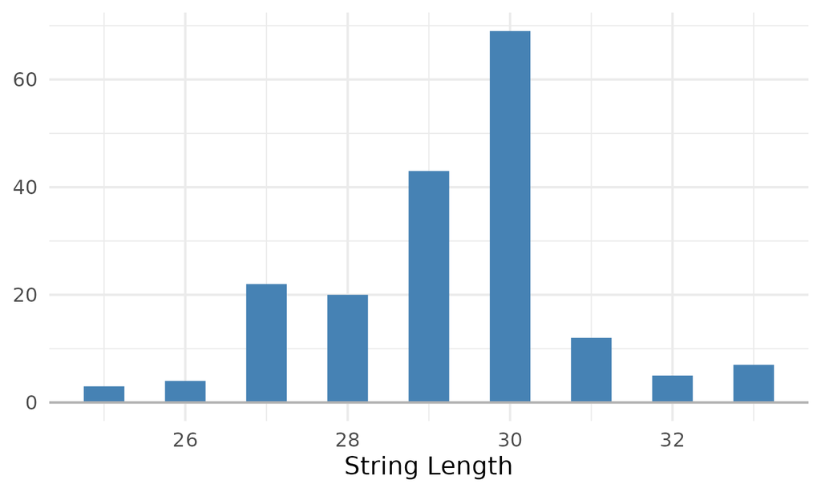

Sample_names  
`character`

| Distinct | 185 |
| --- | --- |
| `NA`s | 0 |
| `Inf`/`-Inf` | 0 |

**Common Values**

| Value | Count | Frequency |
| --- | --- | --- |
| A10-005-B_S188 | 1 | 0.5% |
| A10-005-H_S189 | 1 | 0.5% |
| A10-005-M_S190 | 1 | 0.5% |
| A12-007-B_S2 | 1 | 0.5% |
| A12-007_S191 | 1 | 0.5% |
| A15-004_S3 | 1 | 0.5% |
| A8-005_S4 | 1 | 0.5% |
| A9-012_S5 | 1 | 0.5% |
| AB29-ABMX-H_S6 | 1 | 0.5% |
| **Other Values** (175) | 175 | 94.6% |

**String Lengths**

String Lengths

| Mean | 13.3 |
| --- | --- |
| Minimum | 9.0 |
| Maximum | 17.0 |

Histogram

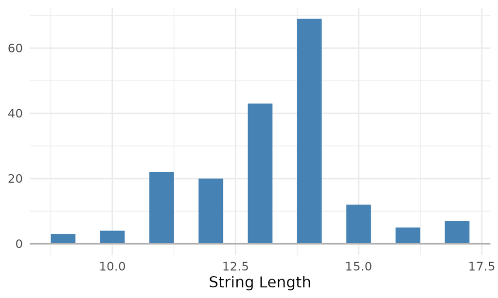

Tree_name  
`character`

| Distinct | 112 |
| --- | --- |
| `NA`s | 0 |
| `Inf`/`-Inf` | 0 |

**Common Values**

| Value | Count | Frequency |
| --- | --- | --- |
| AD30-abm-X | 4 | 2.2% |
| A10-005 | 3 | 1.6% |
| AD26-005 | 3 | 1.6% |
| BB6-019 | 3 | 1.6% |
| BE9-006 | 3 | 1.6% |
| BG7-010 | 3 | 1.6% |
| BL7-006 | 3 | 1.6% |
| BP11-001 | 3 | 1.6% |
| BQ4-018 | 3 | 1.6% |
| **Other Values** (154) | 154 | 83.2% |

**String Lengths**

String Lengths

| Mean | 7.4 |
| --- | --- |
| Minimum | 5.0 |
| Maximum | 11.0 |

Histogram

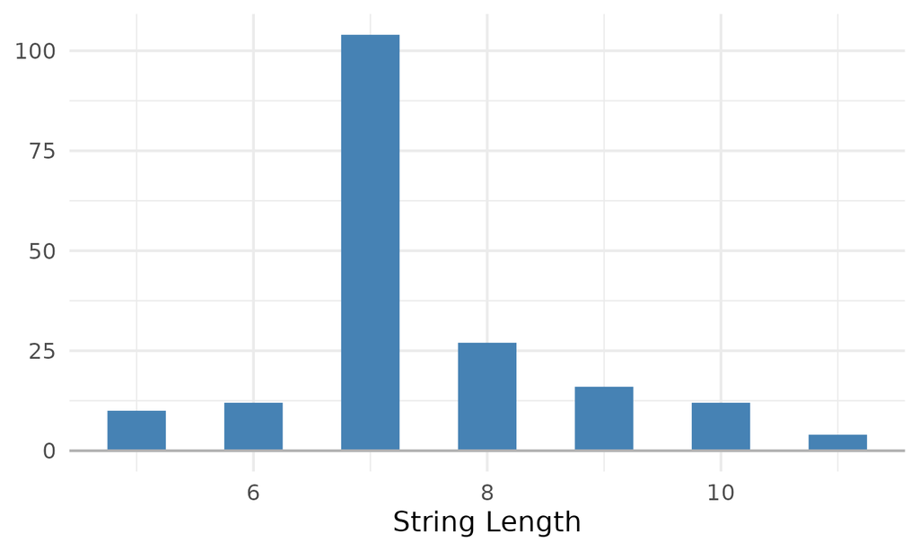

Sample_id  
`integer`

| Distinct | 185 |
| --- | --- |
| `NA`s | 0 |
| `Inf`/`-Inf` | 0 |

| Mean | 96.5 |
| --- | --- |
| Minimum | 2 |
| Maximum | 191 |

**Statistics**

Quantile Statistics

| Minimum | 2.00 |
| --- | --- |
| 5th Percentile | 11.20 |
| Q1 | 48.00 |
| Median | 96.00 |
| Q3 | 145.00 |
| 95th Percentile | 181.80 |
| Maximum | 191.00 |
| Range | 189.00 |
| IQR | 97.00 |

Descriptive Statistics

| Mean | 96.50 |
| --- | --- |
| Variance | 3,098.16 |
| Standard Deviation | 55.66 |
| Coefficient of Variation | 0.58 |

**Common Values**

| Value | Count | Frequency |
| --- | --- | --- |
| 2 | 1 | 0.5% |
| 3 | 1 | 0.5% |
| 4 | 1 | 0.5% |
| 5 | 1 | 0.5% |
| 6 | 1 | 0.5% |
| 7 | 1 | 0.5% |
| 8 | 1 | 0.5% |
| 9 | 1 | 0.5% |
| 10 | 1 | 0.5% |
| **Other Values** (175) | 175 | 94.6% |

**Max/Min Slices**

Maximum Values

| Value | Count | Frequency |
| --- | --- | --- |
| 2 | 1 | 0.54% |
| 3 | 1 | 0.54% |
| 4 | 1 | 0.54% |
| 5 | 1 | 0.54% |
| 6 | 1 | 0.54% |
| 7 | 1 | 0.54% |
| 8 | 1 | 0.54% |
| 9 | 1 | 0.54% |
| 10 | 1 | 0.54% |
| 11 | 1 | 0.54% |

Minimum Values

| Value | Count | Frequency |
| --- | --- | --- |
| 2 | 1 | 0.54% |
| 3 | 1 | 0.54% |
| 4 | 1 | 0.54% |
| 5 | 1 | 0.54% |
| 6 | 1 | 0.54% |
| 7 | 1 | 0.54% |
| 8 | 1 | 0.54% |
| 9 | 1 | 0.54% |
| 10 | 1 | 0.54% |
| 11 | 1 | 0.54% |

Height  
`character`

| Distinct | 4 |
| --- | --- |
| `NA`s | 54 |
| `Inf`/`-Inf` | 0 |

**Common Values**

| Value | Count | Frequency |
| --- | --- | --- |
| `NA` | 54 | 29.2% |
| Low | 45 | 24.3% |
| Middle | 45 | 24.3% |
| High | 41 | 22.2% |
| **Other Values** (0) | 0 | 0.0% |

**String Lengths**

String Lengths

| Mean | 4.3 |
| --- | --- |
| Minimum | 3.0 |
| Maximum | 6.0 |

Histogram

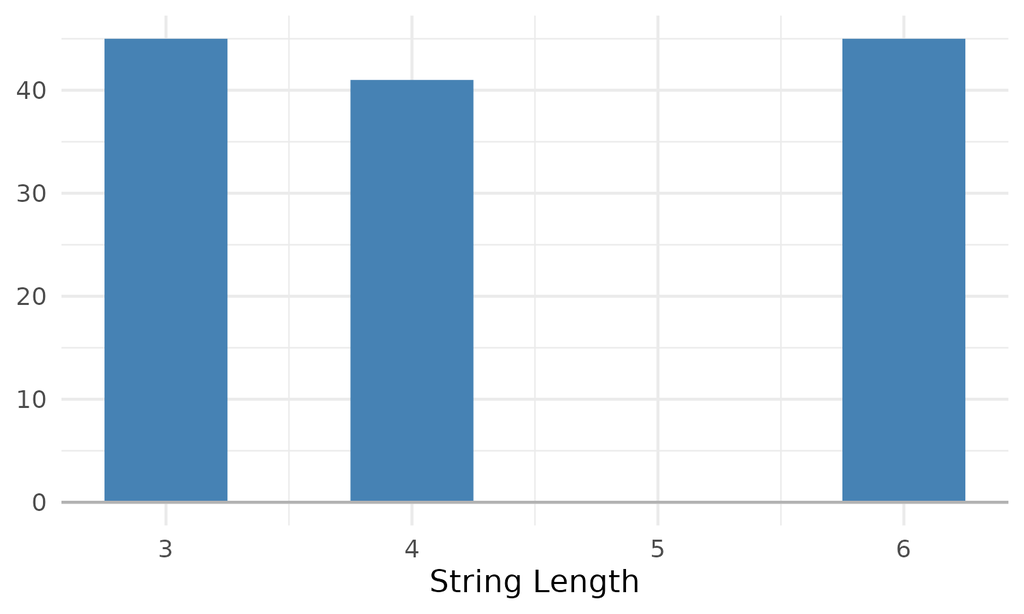

Diameter  
`character`

| Distinct | 78 |
| --- | --- |
| `NA`s | 5 |
| `Inf`/`-Inf` | 0 |

**Common Values**

| Value | Count | Frequency |
| --- | --- | --- |
| 30 | 13 | 7.0% |
| 25 | 8 | 4.3% |
| - | 6 | 3.2% |
| 34 | 6 | 3.2% |
| 32 | 5 | 2.7% |
| 40 | 5 | 2.7% |
| 52 | 5 | 2.7% |
| `NA` | 5 | 2.7% |
| 21,5 | 4 | 2.2% |
| **Other Values** (124) | 124 | 67.0% |

**String Lengths**

String Lengths

| Mean | 3.1 |
| --- | --- |
| Minimum | 1.0 |
| Maximum | 5.0 |

Histogram

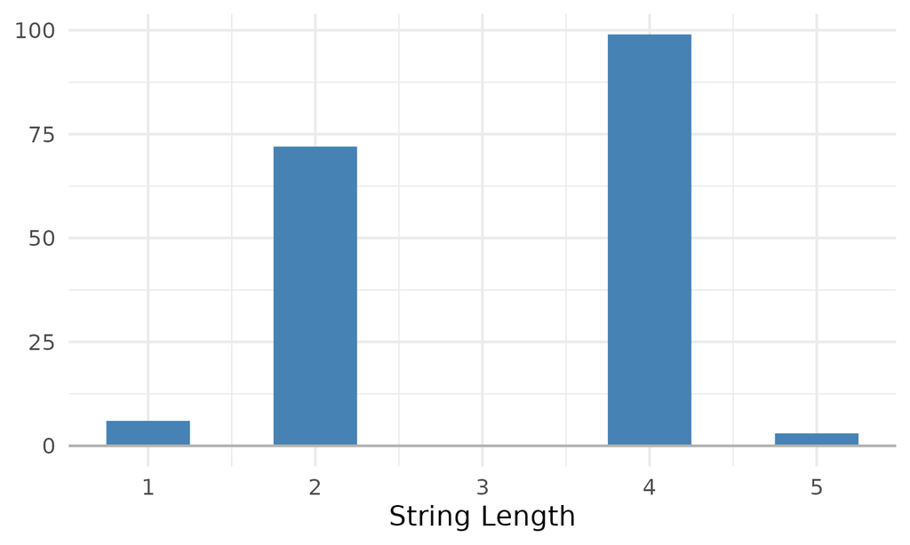

Time  
`integer`

| Distinct | 5 |
| --- | --- |
| `NA`s | 23 |
| `Inf`/`-Inf` | 0 |

| Mean | 5.8 |
| --- | --- |
| Minimum | 0 |
| Maximum | 15 |

**Statistics**

Quantile Statistics

| Minimum | 0.00 |
| --- | --- |
| 5th Percentile | 0.00 |
| Q1 | 0.00 |
| Median | 5.00 |
| Q3 | 10.00 |
| 95th Percentile | 15.00 |
| Maximum | 15.00 |
| Range | 15.00 |
| IQR | 10.00 |

Descriptive Statistics

| Mean | 5.80 |
| --- | --- |
| Variance | 35.38 |
| Standard Deviation | 5.95 |
| Coefficient of Variation | 1.03 |

**Common Values**

| Value | Count | Frequency |
| --- | --- | --- |
| 0 | 67 | 36.2% |
| 5 | 38 | 20.5% |
| 15 | 36 | 19.5% |
| `NA` | 23 | 12.4% |
| 10 | 21 | 11.4% |
| **Other Values** (0) | 0 | 0.0% |

**Max/Min Slices**

Maximum Values

| Value | Count | Frequency |
| --- | --- | --- |
| 0 | 67 | 36.22% |
| 5 | 38 | 20.54% |
| 15 | 36 | 19.46% |
| `NA` | 23 | 12.43% |
| 10 | 21 | 11.35% |

Minimum Values

| Value | Count | Frequency |
| --- | --- | --- |
| 10 | 21 | 11.35% |
| `NA` | 23 | 12.43% |
| 15 | 36 | 19.46% |
| 5 | 38 | 20.54% |
| 0 | 67 | 36.22% |

## Sample

|  | X | Sample_names | Tree_name | Sample_id | Height | Diameter | Time |
| --- | --- | --- | --- | --- | --- | --- | --- |
| 1 | A10-005-B_S188_MERGED.fastq.gz | A10-005-B_S188 | A10-005 | 188 | Low | 52 | 15 |
| 2 | A10-005-H_S189_MERGED.fastq.gz | A10-005-H_S189 | A10-005 | 189 | High | 52 | 15 |
| 3 | A10-005-M_S190_MERGED.fastq.gz | A10-005-M_S190 | A10-005 | 190 | Middle | 52 | 15 |
| 4 | A12-007_S191_MERGED.fastq.gz | A12-007_S191 | A12-007 | 191 | `NA` | 28,4 | 0 |
| 5 | A12-007-B_S2_MERGED.fastq.gz | A12-007-B_S2 | A12-007 | 2 | Low | 28,4 | 0 |
| 6..180 |  |  |  |  |  |  |  |
| 181 | Y29-007-M_S183_MERGED.fastq.gz | Y29-007-M_S183 | Y29-007 | 183 | Middle | 68,6 | 0 |
| 182 | Y31-ABM484-B_S184_MERGED.fastq.gz | Y31-ABM484-B_S184 | Y31-abm484 | 184 | Low | 20 | 5 |
| 183 | Z29-001-H_S185_MERGED.fastq.gz | Z29-001-H_S185 | Z29-001 | 185 | High | 35,2 | 5 |
| 184 | Z30-002_S186_MERGED.fastq.gz | Z30-002_S186 | Z30-002 | 186 | `NA` | 43,4 | 15 |
| 185 | Z30-ABM560-M_S187_MERGED.fastq.gz | Z30-ABM560-M_S187 | Z30-abm560 | 187 | Middle | 11 | 5 |

## Correlations

**Pearson**

**Kendall**

**Spearman**

## Missing Values

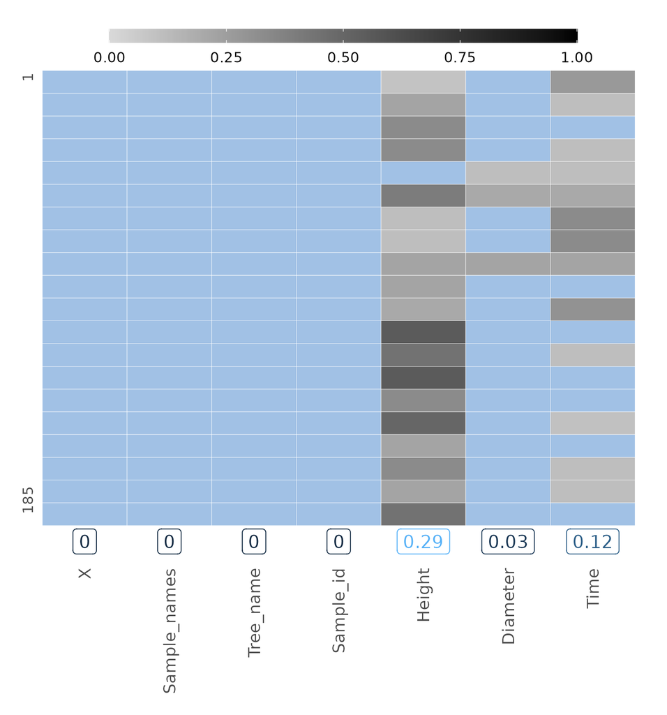

## Interactions

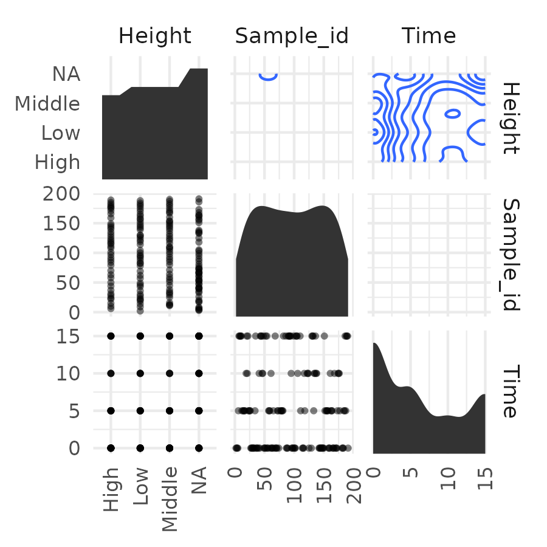

```r
pointblank::create_informant(
  tbl = sam_tab,
  tbl_name = "Sample data",
  label = "data_fungi"
)
```

Pointblank Information

data_fungi tibble Sample dataRows 185 Columns 7

| Columns |
| --- |
| `X` `character` |
| `Sample_names` `character` |
| `Tree_name` `character` |
| `Sample_id` `integer` |
| `Height` `character` |
| `Diameter` `character` |
| `Time` `integer` |

2024-02-13 13:06:36 UTC < 1 s 2024-02-13 13:06:36 UTC

```r
gtExtras::gt_plt_summary(sam_tab)
```

sam_tab

185 rows x 7 cols

Column

Plot Overview

Missing

Mean

Median

SD

**X**

[figure not shown]

0.0%

—

—

—

**Sample_names**

[figure not shown]

0.0%

—

—

—

**Tree_name**

AD30-abm-X, A10-005, AD26-005, BB6-019, BE9-006, BG7-010, BL7-006, BP11-001, BQ4-018, BU11-002, C21-nv-1, CB8-019, D18-003, D9-027, DJ2-008, DS1abm002, DY5-004, E9-009, J18-004, L19-X, L23-002, N19-X, N23-002, O20-X, O21-007, O24-003, O26-004, R28-008, W26-001, X24-009, X29-004, Y28-002, Y29-007, A12-007, BT7-006, C9-005, FOMES19, M22-001, Y31-abm484, A15-004, A8-005, A9-012, AB29-abm-X, AC27-013, AC29-033, AD32-007, AE30-abm507, B18-006, BA16-036, BA17-050, BB19-006, BD14-021, BH9-021, BI7-014, BJ17-007, BJ8abm003, BN11-041, BN9-002, BO8-002, BO8-005, BP12-025, BP14-006, BQ3-019, BQ9abm002, BR8-005, BS14-006, BW8-003, C1-001, CA12-024, CA9-027, CA9-X, CB9-013, CC3-044, CC8-003, D17-011, D22-nvabm-1, DB1abm001, DG1-010, DP4abm001, DU3-045, DW4-007, DZ6abm001, EAabm001, EC2-013, F6abm001, F7-015, H10-018, H24-nvabm-1, K18-002, K26-nvamb-1, N25-abm-X, nvabm0058, nvabm0163, nvabm0216, nvabm0244, nvabm0397, O27-012, P19-023, P27-015, P27-abm001, Q27-abm003, R25-abm-X, T28-011, T28-abm602, U27-abm002, W25-abm-X, W29-025, W30-006, X24-010, Z29-001, Z30-002 and Z30-abm560

[figure not shown]

0.0%

—

—

—

Sample_id

[figure not shown]

0.0%

96.5

96.0

55.7

**Height**

Low, Middle and High

29.2%

—

—

—

**Diameter**

30, 25, -, 34, 32, 40, 52, 21,5, 33,3, 33,5, 115,5, 18,9, 20, 23,1, 27,6, 29,5, 30,4, 33, 33,8, 35, 35,6, 37,2, 38,8, 40,5, 45,5, 47,5, 52,7, 60,4, 63,6, 68,6, 71,7, 75, 76,4, 10, 11, 28,4, 32,5, 39, 41, 50, 18,3, 18,4, 23, 23,4, 25,3, 26,5, 30,7, 32,3, 32,4, 32,8, 35,2, 35,7, 36,3, 36,5, 36,8, 37,5, 37,8, 38, 38,2, 38,3, 40,3, 43, 43,4, 44,3, 55,4, 59,6, 59,8, 60, 64, 64,5, 66,8, 69,5, 71,5, 80, 88,5, 96 and 99

[figure not shown]

2.7%

—

—

—

Time

[figure not shown]

12.4%

5.8

5.0

5.9

#### Explore taxonomic data

```r
tax_tab <- tibble::as_tibble(unclass(data_fungi@tax_table))
```

```r
summarytools::dfSummary(tax_tab)











```

```
#> Warning in png(png_loc <- tempfile(fileext = ".png"), width = 150 *
#> graph.magnif, : unable to open connection to X11 display ''
#> Data Frame Summary
#> tax_tab
#> Dimensions: 1420 x 12
#> Duplicates: 976
#>
#> --------------------------------------------------------------------------------------------------------------------------
#> No   Variable             Stats / Values                  Freqs (% of Valid)   Graph                  Valid      Missing
#> ---- -------------------- ------------------------------- -------------------- ---------------------- ---------- ---------
#> 1    Domain               1. Fungi                        1420 (100.0%)        IIIIIIIIIIIIIIIIIIII   1420       0
#>      [character]                                                                                      (100.0%)   (0.0%)
#>
#> 2    Phylum               1. Ascomycota                   1066 (75.1%)         IIIIIIIIIIIIIII        1420       0
#>      [character]          2. Basidiomycota                 345 (24.3%)         IIII                   (100.0%)   (0.0%)
#>                           3. Monoblepharomycota              1 ( 0.1%)
#>                           4. Mortierellomycota               1 ( 0.1%)
#>                           5. Mucoromycota                    3 ( 0.2%)
#>                           6. Rozellomycota                   4 ( 0.3%)
#>
#> 3    Class                1. Sordariomycetes              297 (22.4%)          IIII                   1327       93
#>      [character]          2. Agaricomycetes               245 (18.5%)          III                    (93.5%)    (6.5%)
#>                           3. Dothideomycetes              207 (15.6%)          III
#>                           4. Leotiomycetes                149 (11.2%)          II
#>                           5. Eurotiomycetes               121 ( 9.1%)          I
#>                           6. Lecanoromycetes              117 ( 8.8%)          I
#>                           7. Tremellomycetes               45 ( 3.4%)
#>                           8. Saccharomycetes               42 ( 3.2%)
#>                           9. Orbiliomycetes                30 ( 2.3%)
#>                           10. Dacrymycetes                 24 ( 1.8%)
#>                           [ 15 others ]                    50 ( 3.8%)
#>
#> 4    Order                1. Pleosporales                 132 (10.7%)          II                     1231       189
#>      [character]          2. Helotiales                   126 (10.2%)          II                     (86.7%)    (13.3%)
#>                           3. Chaetothyriales               73 ( 5.9%)          I
#>                           4. Xylariales                    53 ( 4.3%)
#>                           5. Capnodiales                   49 ( 4.0%)
#>                           6. Russulales                    45 ( 3.7%)
#>                           7. Agaricales                    43 ( 3.5%)
#>                           8. Saccharomycetales             42 ( 3.4%)
```

[output cut: 71 more lines]

```
#>                           3. Possible                     233 (16.4%)          III
#>                           4. Probable                     653 (46.0%)          IIIIIIIII
#>
#> 12   Genus_species        1. NA_NA                        410 (28.9%)          IIIII                  1420       0
#>      [character]          2. Coniochaeta_NA                36 ( 2.5%)                                 (100.0%)   (0.0%)
#>                           3. Neocucurbitaria_NA            29 ( 2.0%)
#>                           4. Lentomitella_NA               16 ( 1.1%)
#>                           5. Penicillium_NA                16 ( 1.1%)
#>                           6. Eutypa_spinosa                15 ( 1.1%)
#>                           7. Hyperphyscia_adglutinata      15 ( 1.1%)
#>                           8. Dacrymyces_stenosporus        14 ( 1.0%)
#>                           9. Penicillium_brevicompactu     14 ( 1.0%)
#>                           10. Exophiala_NA                 13 ( 0.9%)
#>                           [ 364 others ]                  842 (59.3%)          IIIIIIIIIII
#> --------------------------------------------------------------------------------------------------------------------------
```

```r
datawizard::data_codebook(tax_tab)
```

```
#> tax_tab (1420 rows and 12 variables, 12 shown)
#>
#> ID | Name               | Type      |    Missings |                                                                                        Values |             N
#> ---+--------------------+-----------+-------------+-----------------------------------------------------------------------------------------------+--------------
#> 1  | Domain             | character |    0 (0.0%) |                                                                                         Fungi | 1420 (100.0%)
#> ---+--------------------+-----------+-------------+-----------------------------------------------------------------------------------------------+--------------
#> 2  | Phylum             | character |    0 (0.0%) |                                                                                    Ascomycota | 1066 ( 75.1%)
#>    |                    |           |             |                                                                                 Basidiomycota |  345 ( 24.3%)
#>    |                    |           |             |                                                                            Monoblepharomycota |    1 (  0.1%)
#>    |                    |           |             |                                                                             Mortierellomycota |    1 (  0.1%)
#>    |                    |           |             |                                                                                  Mucoromycota |    3 (  0.2%)
#>    |                    |           |             |                                                                                 Rozellomycota |    4 (  0.3%)
#> ---+--------------------+-----------+-------------+-----------------------------------------------------------------------------------------------+--------------
#> 3  | Class              | character |   93 (6.5%) |                                                                                Agaricomycetes |  245 ( 18.5%)
#>    |                    |           |             |                                                                          Agaricostilbomycetes |    5 (  0.4%)
#>    |                    |           |             |                                                                               Arthoniomycetes |    5 (  0.4%)
#>    |                    |           |             |                                                                            Atractiellomycetes |    6 (  0.5%)
#>    |                    |           |             |                                                                           Cystobasidiomycetes |    5 (  0.4%)
#>    |                    |           |             |                                                                                  Dacrymycetes |   24 (  1.8%)
#>    |                    |           |             |                                                                               Dothideomycetes |  207 ( 15.6%)
#>    |                    |           |             |                                                                                Eurotiomycetes |  121 (  9.1%)
#>    |                    |           |             |                                                                               Lecanoromycetes |  117 (  8.8%)
#>    |                    |           |             |                                                                                 Leotiomycetes |  149 ( 11.2%)
#>    |                    |           |             |                                                                                         (...) |
#> ---+--------------------+-----------+-------------+-----------------------------------------------------------------------------------------------+--------------
#> 4  | Order              | character | 189 (13.3%) |                                                                                    Agaricales |   43 (  3.5%)
```

[output cut: 93 more lines]

```r
pillar::glimpse(tax_tab)
```

```
#> Rows: 1,420
#> Columns: 12
#> $ Domain             <chr> "Fungi", "Fungi", "Fungi", "Fungi", "Fungi", "Fungi…
#> $ Phylum             <chr> "Ascomycota", "Ascomycota", "Basidiomycota", "Basid…
#> $ Class              <chr> "Sordariomycetes", "Sordariomycetes", "Agaricomycet…
#> $ Order              <chr> "Xylariales", "Xylariales", "Russulales", "Russulal…
#> $ Family             <chr> "Diatrypaceae", "Xylariaceae", "Stereaceae", "Stere…
#> $ Genus              <chr> "Eutypa", "Xylaria", NA, "Stereum", NA, "Xylodon", …
#> $ Species            <chr> "spinosa", NA, NA, "ostrea", NA, "raduloides", NA, …
#> $ Trophic.Mode       <chr> "Pathotroph", "Saprotroph-Symbiotroph", "Saprotroph…
#> $ Guild              <chr> "Plant Pathogen", "Endophyte-Undefined Saprotroph-W…
#> $ Trait              <chr> "NULL", "Soft Rot", "NULL", "White Rot", "-", "Whit…
#> $ Confidence.Ranking <chr> "Probable", "Probable", "Probable", "Probable", "-"…
#> $ Genus_species      <chr> "Eutypa_spinosa", "Xylaria_NA", "NA_NA", "Stereum_o…
```

```r
pointblank::scan_data(tax_tab, sections = "OVSCM")
```

## Overview of `tax_tab`

**Overview**

Table Overview

| Columns | 12 |
| --- | --- |
| Rows | 1,420 |
| `NA`s | 1,778 (10.43%) |
| Duplicate Rows | 976 (68.73%) |

Column Types

| character | 12 |
| --- | --- |

**Reproducibility**

Reproducibility Information

| Scan Build Time | `2024-02-13 13:06:38` |
| --- | --- |
| **pointblank** Version | `0.11.4` |
| **R** Version | R version 4.3.2 (2023–10–31) *Eye Holes* |
| Operating System | `x86_64-pc-linux-gnu` |

## Variables

Domain  
`character`

| Distinct | 1 |
| --- | --- |
| `NA`s | 0 |
| `Inf`/`-Inf` | 0 |

**Common Values**

| Value | Count | Frequency |
| --- | --- | --- |
| Fungi | 1420 | 100.0% |
| **Other Values** (0) | 0 | 0.0% |

**String Lengths**

String Lengths

| Mean | 5.0 |
| --- | --- |
| Minimum | 5.0 |
| Maximum | 5.0 |

Histogram

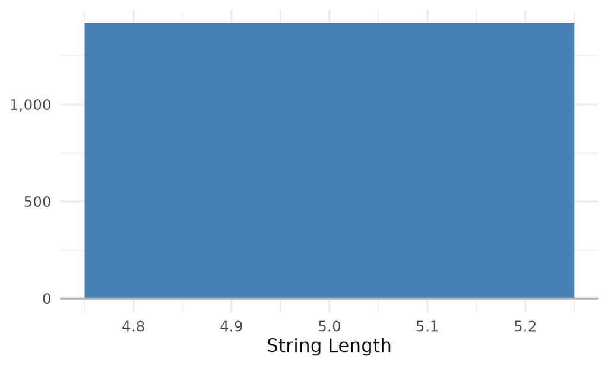

Phylum  
`character`

| Distinct | 6 |
| --- | --- |
| `NA`s | 0 |
| `Inf`/`-Inf` | 0 |

**Common Values**

| Value | Count | Frequency |
| --- | --- | --- |
| Ascomycota | 1066 | 75.1% |
| Basidiomycota | 345 | 24.3% |
| Rozellomycota | 4 | 0.3% |
| Mucoromycota | 3 | 0.2% |
| Monoblepharomycota | 1 | 0.1% |
| Mortierellomycota | 1 | 0.1% |
| **Other Values** (0) | 0 | 0.0% |

**String Lengths**

String Lengths

| Mean | 10.8 |
| --- | --- |
| Minimum | 10.0 |
| Maximum | 18.0 |

Histogram

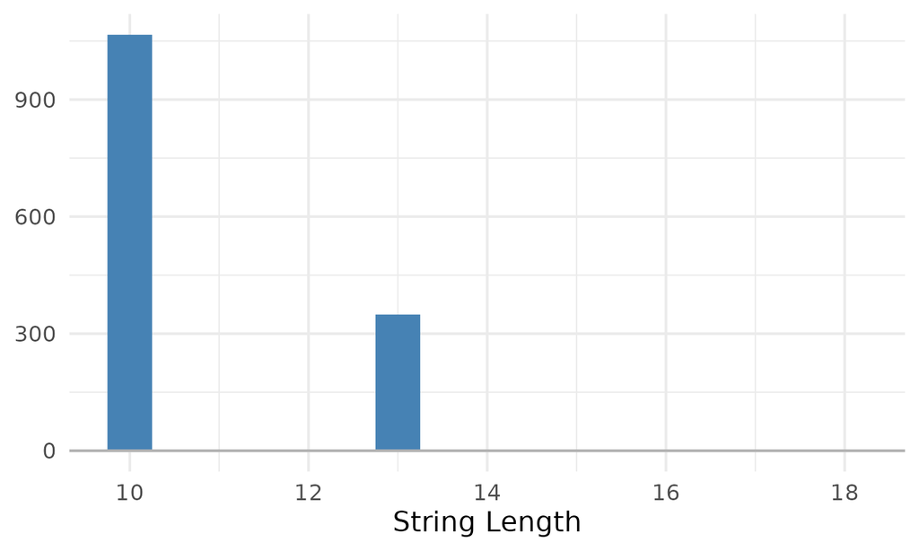

Class  
`character`

| Distinct | 26 |
| --- | --- |
| `NA`s | 93 |
| `Inf`/`-Inf` | 0 |

**Common Values**

| Value | Count | Frequency |
| --- | --- | --- |
| Sordariomycetes | 297 | 20.9% |
| Agaricomycetes | 245 | 17.3% |
| Dothideomycetes | 207 | 14.6% |
| Leotiomycetes | 149 | 10.5% |
| Eurotiomycetes | 121 | 8.5% |
| Lecanoromycetes | 117 | 8.2% |
| `NA` | 93 | 6.5% |
| Tremellomycetes | 45 | 3.2% |
| Saccharomycetes | 42 | 3.0% |
| **Other Values** (74) | 74 | 5.2% |

**String Lengths**

String Lengths

[output not shown]

Histogram

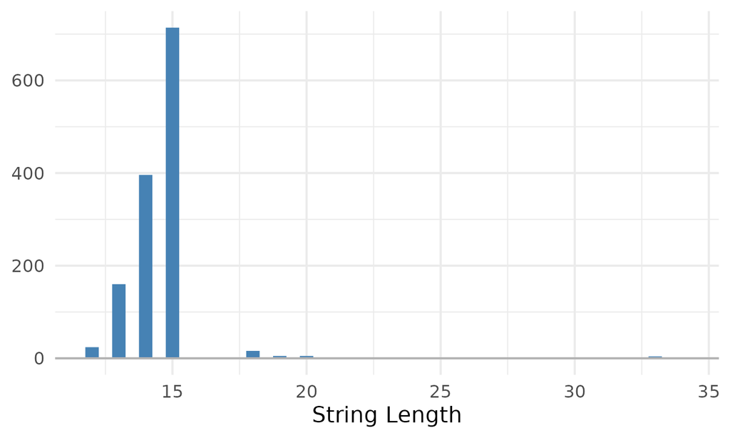

Order  
`character`

| Distinct | 74 |
| --- | --- |
| `NA`s | 189 |
| `Inf`/`-Inf` | 0 |

**Common Values**

| Value | Count | Frequency |
| --- | --- | --- |
| `NA` | 189 | 13.3% |
| Pleosporales | 132 | 9.3% |
| Helotiales | 126 | 8.9% |
| Chaetothyriales | 73 | 5.1% |
| Xylariales | 53 | 3.7% |
| Capnodiales | 49 | 3.5% |
| Russulales | 45 | 3.2% |
| Agaricales | 43 | 3.0% |
| Saccharomycetales | 42 | 3.0% |
| **Other Values** (629) | 629 | 44.3% |

**String Lengths**

String Lengths

| Mean | 12.8 |
| --- | --- |
| Minimum | 4.0 |
| Maximum | 38.0 |

Histogram

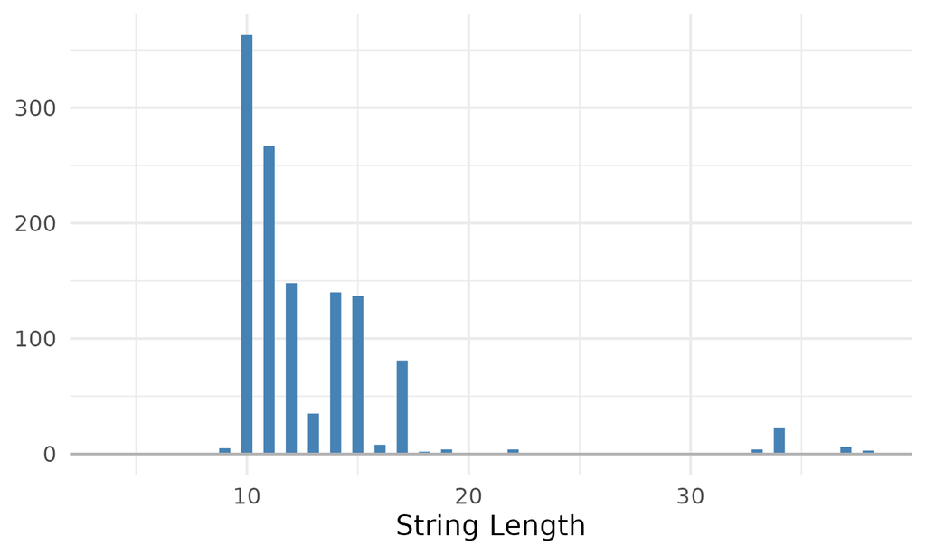

Family  
`character`

| Distinct | 164 |
| --- | --- |
| `NA`s | 317 |
| `Inf`/`-Inf` | 0 |

**Common Values**

| Value | Count | Frequency |
| --- | --- | --- |
| `NA` | 317 | 22.3% |
| Herpotrichiellaceae | 64 | 4.5% |
| Coniochaetaceae | 38 | 2.7% |
| Stereaceae | 35 | 2.5% |
| Aspergillaceae | 34 | 2.4% |
| Cucurbitariaceae | 34 | 2.4% |
| Helotiaceae | 30 | 2.1% |
| Pleurotheciaceae | 30 | 2.1% |
| Orbiliaceae | 29 | 2.0% |
| **Other Values** (780) | 780 | 54.9% |

**String Lengths**